# R Notebook

- You have been provided some customer data from a shopping centre. Do some exploratory analysis on the data. Comment on findings.
- We are interested in creating a marketing campaign to target customers based on their spending score and annual income. Perform a k-means clustering to find if there are meaningful clusters in the data to target the customers.
- Perform k-means clustering and chose a value of k.
- Visualise the clustering for your chosen value of k.
- Do you think the clustering seems a good fit for this data?
- Comment on the attributes on one or two of the clusters (maybe even give them a label if you like - like in section 4.1 of the ‘Segmentation & clustering intro’ lesson).

```r
library(tidyverse)
library(broom)

shopping <- read_csv("mall_customers.csv") %>%
  janitor::clean_names() %>%
  select(-customer_id) %>%
  mutate(gender = recode(gender, "Male" = 0, "Female" = 1))
glimpse(shopping)
```

```
Rows: 200
Columns: 4
$ gender               <dbl> 0, 0, 1, 1, 1, 1, 1, 1, 0, 1, 0, 1, 1, 1, 0, 0, 1, 0, 0, 1…
$ age                  <dbl> 19, 21, 20, 23, 31, 22, 35, 23, 64, 30, 67, 35, 58, 24, 37…
$ annual_income_k      <dbl> 15, 15, 16, 16, 17, 17, 18, 18, 19, 19, 19, 19, 20, 20, 20…
$ spending_score_1_100 <dbl> 39, 81, 6, 77, 40, 76, 6, 94, 3, 72, 14, 99, 15, 77, 13, 7…
```

# Exploring the data

It appears that those earning under 50k appear to fall in a wide range on the spending score. Those earning around 45k to around 60k tend to fall around the 30 to 60 range. Those earning over about 70k appear to spend a varied amount similar to those earning under 50k. Gender does not seem to be a big factor in this dataset.

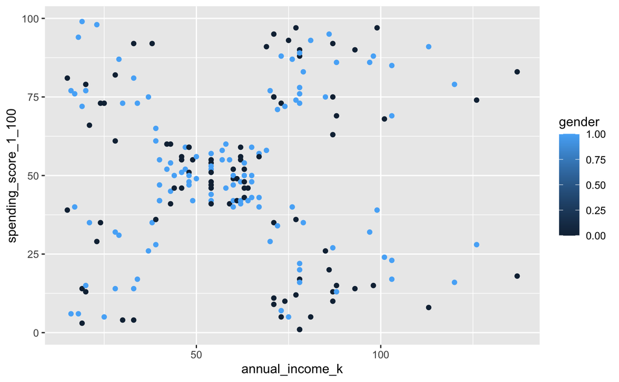

```r
shopping %>%
  ggplot(aes(annual_income_k, spending_score_1_100, colour = gender)) +
  geom_point()
```

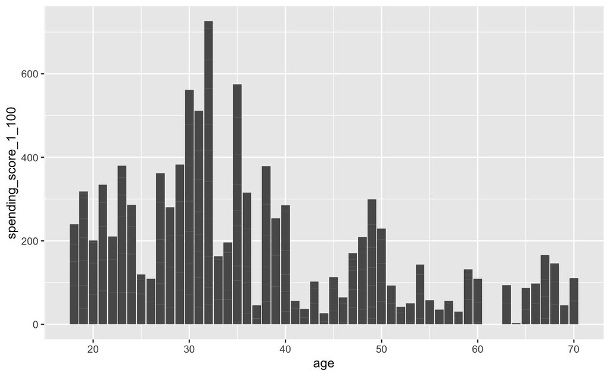

```r
shopping %>%
  ggplot(aes(age, spending_score_1_100)) +
  geom_col()
```

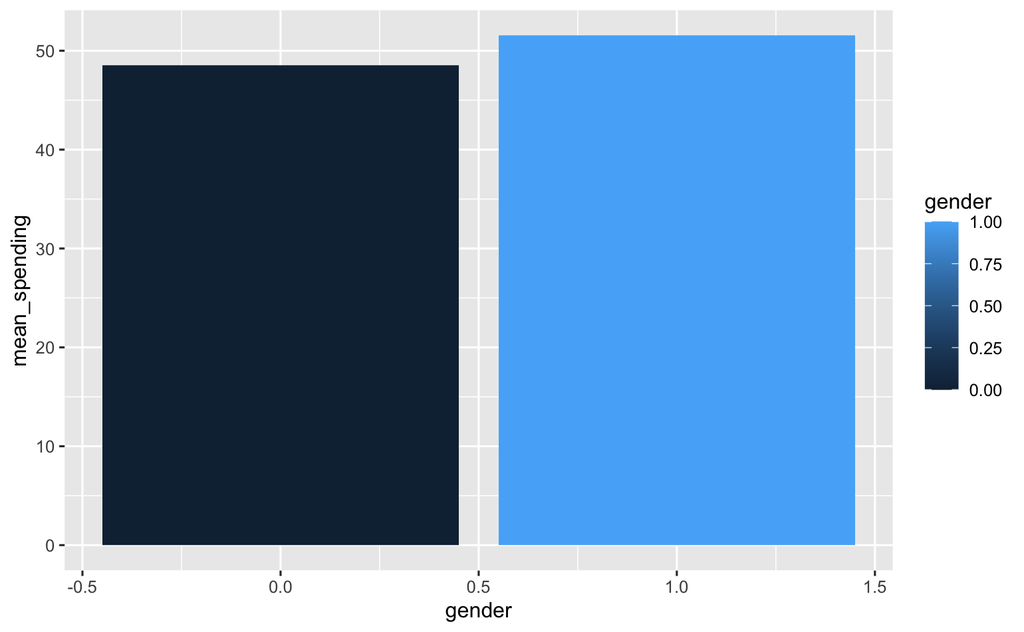

```r
shopping %>%
  group_by(gender) %>%
  summarise(mean_spending = mean(spending_score_1_100)) %>%
  ggplot(aes(gender, mean_spending, fill = gender)) +
  geom_col()
```

# Preparing data for clustering and dropping age and gender as these will not be beneficial to the aim of the K-means clustering.

Scaling the data - gender has been turned into a binary since the k means clustering method will not produce good results with categoricals.

```r
summary(shopping)
```

```
     gender          age        annual_income_k  spending_score_1_100
 Min.   :0.00   Min.   :18.00   Min.   : 15.00   Min.   : 1.00
 1st Qu.:0.00   1st Qu.:28.75   1st Qu.: 41.50   1st Qu.:34.75
 Median :1.00   Median :36.00   Median : 61.50   Median :50.00
 Mean   :0.56   Mean   :38.85   Mean   : 60.56   Mean   :50.20
 3rd Qu.:1.00   3rd Qu.:49.00   3rd Qu.: 78.00   3rd Qu.:73.00
 Max.   :1.00   Max.   :70.00   Max.   :137.00   Max.   :99.00
```

```r
shopping_scaled <- shopping %>%
  select(-c(age, gender)) %>%
  mutate_all(scale) %>%

summary(shopping_scaled)
```

# Performing K-means clustering on the data

```r
shopping_clustered
```

```
K-means clustering with 6 clusters of sizes 22, 81, 23, 35, 10, 29

Cluster means:
  annual_income_k spending_score_1_100
1      -1.3262173           1.12934389
2      -0.2004097          -0.02638995
3      -1.3042458          -1.13411939
4       1.0523622          -1.28122394
5       1.8709508           1.23143545
6       0.6850149           1.23811207

Clustering vector:
  [1] 3 1 3 1 3 1 3 1 3 1 3 1 3 1 3 1 3 1 3 1 3 1 3 1 3 1 3 1 3 1 3 1 3 1 3 1 3 1 3 1 3 1
 [43] 3 2 3 1 2 2 2 2 2 2 2 2 2 2 2 2 2 2 2 2 2 2 2 2 2 2 2 2 2 2 2 2 2 2 2 2 2 2 2 2 2 2
 [85] 2 2 2 2 2 2 2 2 2 2 2 2 2 2 2 2 2 2 2 2 2 2 2 2 2 2 2 2 2 2 2 2 2 2 2 2 2 2 2 6 4 6
[127] 2 6 4 6 4 6 2 6 4 6 4 6 4 6 4 6 2 6 4 6 4 6 4 6 4 6 4 6 4 6 4 6 4 6 4 6 4 6 4 6 4 6
[169] 4 6 4 6 4 6 4 6 4 6 4 6 4 5 4 5 4 5 4 5 4 5 4 5 4 5 4 5 4 5 4 5

Within cluster sum of squares by cluster:
[1]  5.217630 14.485632  7.577407 18.304646  3.681858  5.514889
 (between_SS / total_SS =  86.2 %)

Available components:

[1] "cluster"      "centers"      "totss"        "withinss"     "tot.withinss"
[6] "betweenss"    "size"         "iter"         "ifault"
```

```r
tidy(shopping_clustered,
     col.names = colnames(shopping_scaled))
```

| annual_income_k.V1 | spending_score_1_100.V1 | size | withinss | cluster |
| --- | --- | --- | --- | --- |
| -1.3262173 | 1.12934389 | 22 | 5.217630 | 1 |
| -0.2004097 | -0.02638995 | 81 | 14.485632 | 2 |
| -1.3042458 | -1.13411939 | 23 | 7.577407 | 3 |
| 1.0523622 | -1.28122394 | 35 | 18.304646 | 4 |
| 1.8709508 | 1.23143545 | 10 | 3.681858 | 5 |
| 0.6850149 | 1.23811207 | 29 | 5.514889 | 6 |

```r
glance(shopping_clustered)
```

| totss | tot.withinss | betweenss | iter |
| --- | --- | --- | --- |
| 398 | 54.78206 | 343.2179 | 3 |

```r
augment(shopping_clustered, shopping)
```

| gender | age | annual_income_k | spending_score_1_100 | .cluster |
| --- | --- | --- | --- | --- |
| 0 | 19 | 15 | 39 | 3 |
| 0 | 21 | 15 | 81 | 1 |
| 1 | 20 | 16 | 6 | 3 |
| 1 | 23 | 16 | 77 | 1 |
| 1 | 31 | 17 | 40 | 3 |
| 1 | 22 | 17 | 76 | 1 |
| 1 | 35 | 18 | 6 | 3 |
| 1 | 23 | 18 | 94 | 1 |
| 0 | 64 | 19 | 3 | 3 |
| 1 | 30 | 19 | 72 | 1 |

[output cut: 190 more lines]

# Determining the K value

The K value will be 5.

```r
library(factoextra)

#Unsure what the augment argument is meant to be, it is not accepting a variable name.

k_clusters <- tibble(k = 1:5) %>%
  mutate(
    kclust = map(k, ~ kmeans(shopping_scaled, .x, nstart = 25)),
    tidied = map(kclust, tidy),
    glanced = map(kclust, glance),
    augmented = map(kclust, augment, shopping_scaled)
  )

clusterings <- k_clusters %>%
  unnest(glanced)

clusterings
```

| k | kclust | tidied | totss | tot.withinss | betweenss | iter | augmented |
| --- | --- | --- | --- | --- | --- | --- | --- |
| 1 |  |  | 398 | 398.00000 | -2.273737e-13 | 1 |  |
| 2 |  |  | 398 | 267.67171 | 1.303283e+02 | 1 |  |
| 3 |  |  | 398 | 156.91549 | 2.410845e+02 | 4 |  |
| 4 |  |  | 398 | 108.37671 | 2.896233e+02 | 2 |  |
| 5 |  |  | 398 | 65.24057 | 3.327594e+02 | 3 |  |

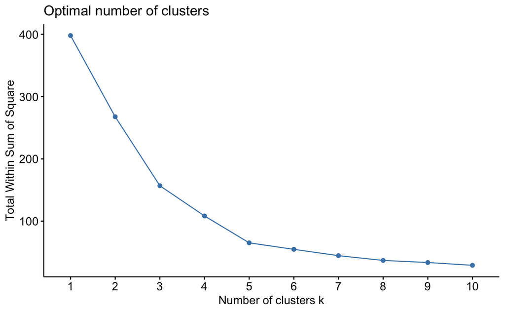

```r
#Silhouette method

 silhoutte <- fviz_nbclust(shopping_scaled, kmeans, method = "silhouette", nstart = 25)

#Elbow Method

fviz_nbclust(shopping_scaled, kmeans, method = "wss", nstart = 25)
```

# Visualising clustering

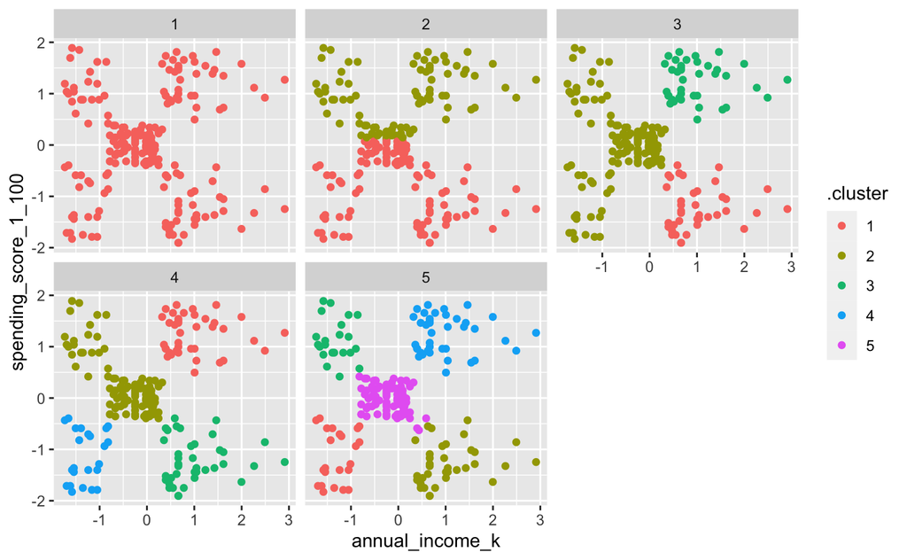

```r
clusterings %>%
  unnest(cols = c(augmented)) %>%
  filter(k <= 5) %>%
 ggplot(aes(x = annual_income_k, y = spending_score_1_100)) +
  geom_point(aes(color = .cluster)) +
  facet_wrap(~ k)
```

```r
clusterings %>%
  unnest(augmented) %>%
  filter(k <= 5) %>%
  group_by(.cluster) %>%
  summarise(mean(spending_score_1_100), mean(annual_income_k))
```

| .cluster | mean(spending_score_1_100) | mean(annual_income_k) |
| --- | --- | --- |
| 1 | -0.25431840 | 0.1087412 |
| 2 | 0.16690545 | -0.2440591 |
| 3 | 0.26880199 | 0.4813308 |
| 4 | 0.35701385 | 0.1383433 |
| 5 | -0.02638995 | -0.2004097 |

The clustering has given a clear distinction between low earners who have a low spending score, low earners with a high income score, those who are in the middle region of income and sit around 50 on the spending score, high earners with a low spending score and high earnings who are spending a lot. I would say this is a pretty accurate way to depict this data given the conclusions drawn earlier are pretty similar to the clustering findings.